# Ass4.1: Principal Components Analysis

Assignment 4.1: ESM 244 Data Analysis

Author

Logan Ruggles

# 1 Overview

## 1.1 Purpose

Perform PCA create biplot, interpret results

See which happiness factors most explain happiness

## 1.2 Data

Life evaluation: average of 1000 surveys from each country, evaluate current life from 0 to 10 (Centril ladder), 3-year average and weighted

Log GDP per capita: World Development Indicators (WDI) from World Bank, in terms of Purchasing Power Parity Social support: Gallup World Poll “If you were in trouble, do you have relatives or friends you can count on to help you whenever you need them, or not?”, binary Y1 N0, national avg Healthy life expectancy at birth: Global Health Observatory data from World Health Organization Freedom to make life choices: “Are you satisfied or dissatisfied with your freedom to choose what you do with your life?” binary Y1 N0, national average Generosity: residual of regressing national average, “Have you donated money to a charity in the past month?”, on log GDP per capita. Perception of corruption: average of binary responses “Is corruption widespread throughout the government in this country or not?” and “Is corruption widespread within businesses in this country or not?”. NAs - perception of business corruption used

Based on data viz, dystopia and gdp may be most representative

Bias in chosen variables possible, based on individual perception, unclear where discrimination for example factors in. Scores compared to a fictional rock-bottom countries, then combined into one score. Rankings take averages of data from 3 previous years. Northern European countries have tended to dominate the happiness rankings due to strong social support systems and high standards of living, while African countries are lowest. Finland most happy in 2023, Afghanistan least happy (low life expectancy rate and low GDP)

Data Source:

Website: https://worldpopulationreview.com/country-rankings/happiest-countries-in-the-world Metadata https://worldhappiness.report/ed/2022/happiness-benevolence-and-trust-during-covid-19-and-beyond/#ranking-of-happiness-2019-2021

cont_count https://github.com/datawookie/data-diaspora/blob/master/spatial/country-continent-codes.csv

countries_sf https://hub.arcgis.com/datasets/esri::world-countries-generalized/explore

## 1.3 Pseudocode

## 1.4 Code

```r
library(tidyverse)
library(janitor)
library(here)
library(sf)
library(lubridate)
library(ggfortify) # For PCA biplot
```

# 2 Visualizing Global Happiness Scores

```r
happy_scores <- read_csv(here('happy_scores.csv')) %>%
  janitor::clean_names() %>%
  select(c(country, happiest_countries_world_happiess_report_score2022)) %>%
  rename("score_2022" = "happiest_countries_world_happiess_report_score2022")

countries_sf <- read_sf(here('countries', 'World_Countries_Generalized.shp')) %>%
  janitor::clean_names() %>%
  select(country, geometry)


#st_crs(countries_sf) #3857
countries_4326_sf <- st_transform(countries_sf, 4326)
#st_crs(countries_4326_sf) #WGS84
```

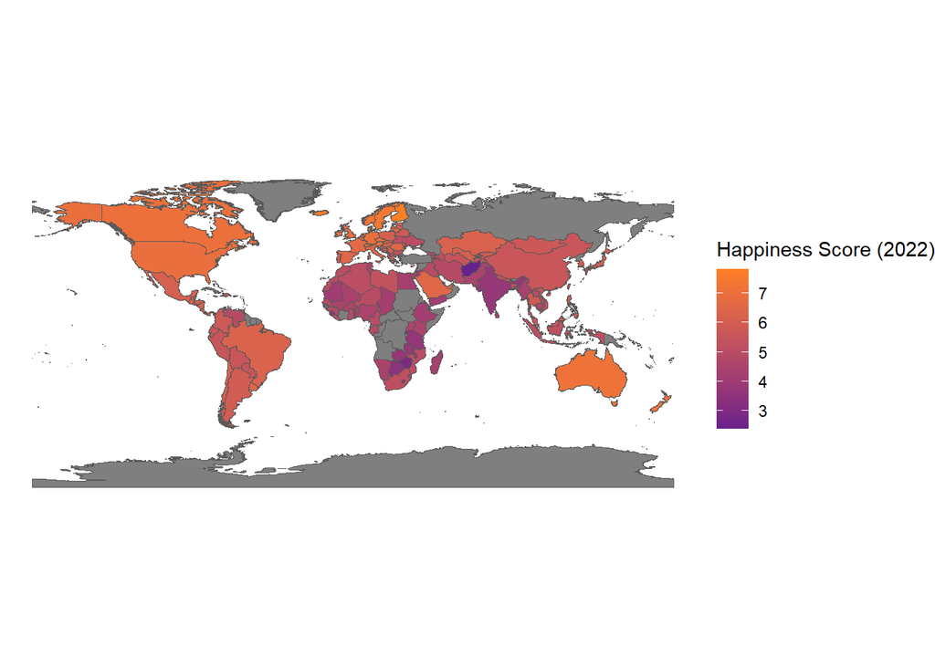

World Happiness Scores (2022)

```r
country_score_sf <- full_join(countries_4326_sf, happy_scores, by="country")

ggplot() +
  geom_sf(data = country_score_sf, aes(fill = score_2022), size = 1) + # size = border
  scale_fill_gradientn(colors = c('darkorchid4', 'chocolate1')) +
  theme_void() +
  labs(fill = 'Happiness Score (2022)')
```

```r
## ERROR: WANT 3857 PROJECTION
```

# 3 PCA Code

- professional biplot with caption, screeplot optional

```r
#data exploration
happy_raw <- read_csv(here('happy.csv')) %>%
  janitor::clean_names() %>%
  mutate(year = as.factor(year)) # so year in its own column in happy_long

count_cont_df <- read_csv(here("country_continent.csv")) %>%
  janitor::clean_names() %>%
  select(country, continent) %>%
  mutate(country = str_trim(str_remove(country, ",.+|\\(.+"))) # comma OR (|) front parentheses [\\( so not confused ofr coding parentheses] and make everything after it blank (periods for everything after)

# count_cont_clean_df <- count_cont_df %>%
#   mutate(country = as.factor(country)) %>% # does making a factor make it work?
#   mutate(continent = as.factor(continent)) %>%
#   mutate(country = str_trim(str_remove(country, ",.+|\\(.+"))) # comma OR (|) front parentheses [\\( so not confused ofr coding parentheses] and make everything after it blank (periods for everything after)

#summary(happy_raw)
#most NAs for perception of corruption

# happy_long <- happy_raw %>%
#  pivot_longer(names_to = 'name', values_to = 'value', where(is.numeric))
```

```r
# ggplot(happy_long, aes(x=value)) +
#   geom_histogram() +
#   facet_wrap(~ name, scales = "free")

# skew: freedom, life exp, gdp, neg effect, perceptions, social
# more even: generosity, life ladder, pos
```

MAKE PURTY

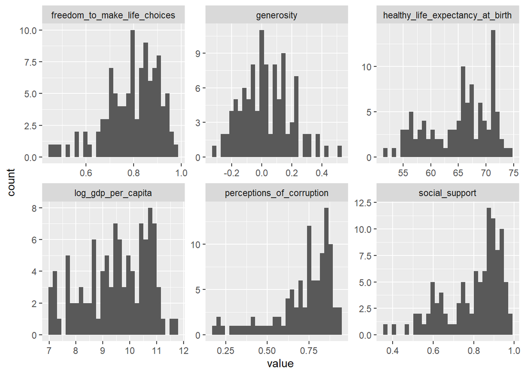

```r
# select target variables, for year 2022, drop rows with NAs

happy_2022 <- happy_raw %>% #2199 obs
  select(-c(life_ladder, positive_affect, negative_affect)) %>% #6 variables, no NAs for these
  filter(year == "2022") %>% #114 obs
  drop_na() #104 obs (10 dropped)

##### ERRORRRRR
happy_join <- left_join(happy_2022, count_cont_df, by=c("country_name"="country"))

happy_anti <- anti_join(happy_2022, count_cont_df, by=c("country_name"="country")) # 9 countries not brought over, armenia, khazikstan and georgia repeat

happy_long_2022 <- happy_2022 %>%
  pivot_longer(names_to = 'name', values_to = 'value', where(is.numeric))

ggplot(happy_long_2022, aes(x=value)) +
  geom_histogram() +
  facet_wrap(~ name, scales = "free")
```

```r
# generosity even, others left skewed
```

```r
# rescale to mean 0 and sd 1
happy_pca <- happy_2022 %>%
  select(where(is.numeric)) %>%
  prcomp(scale = TRUE)
```

- `sdev` is the standard deviation (square root of explained variance captured by each principal component)
- `rotation` is the translation of base variables to principal components (and vice versa)
- `center` is the factor applied for centering of the variables
- `scale` is the factor for rescaling of the variables
- `x` is a dataframe of all observations transformed to their new values in PC1, 2, etc.

```r
# See the loadings (weighting for each principal component)
happy_pca$rotation
```

```
                                         PC1        PC2         PC3        PC4
log_gdp_per_capita               -0.51469330  0.2285593 -0.11552090  0.1985848
social_support                   -0.48636432  0.1308559  0.38018887  0.2007510
healthy_life_expectancy_at_birth -0.50355163  0.2275586 -0.05470505  0.1900730
freedom_to_make_life_choices     -0.36055731 -0.3274529  0.41504921 -0.7447770
generosity                       -0.05199466 -0.7768162  0.24956031  0.5494663
perceptions_of_corruption         0.33506908  0.4101043  0.77754261  0.1659195
                                         PC5         PC6
log_gdp_per_capita               -0.08517531 -0.78918668
social_support                    0.69714570  0.27471769
healthy_life_expectancy_at_birth -0.62278961  0.51736401
freedom_to_make_life_choices     -0.16654325 -0.08987591
generosity                       -0.15622823 -0.07247239
perceptions_of_corruption        -0.25830646 -0.14394141
```

What can we say about the contributions of these variables to PC1, PC2, and PC3?

?? is it the ones closer together? or the one they most input into is their order? no cuz it’s pieces of them

## 3.1 Biplot loadings by hand

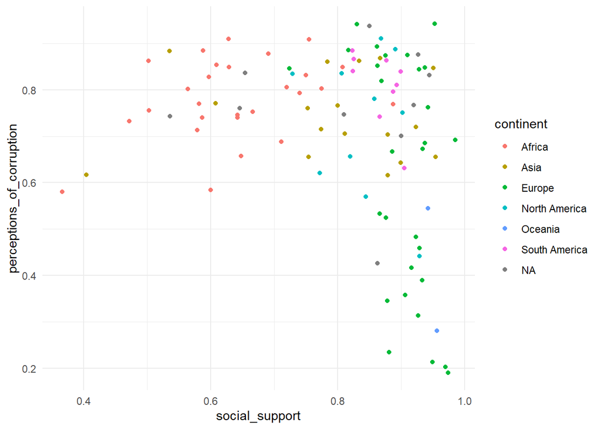

```r
# plot raw data with sample of variables
ggplot() +
  geom_point(data = happy_join, aes(x = social_support, y = perceptions_of_corruption, color = continent)) +
  theme_minimal()
```

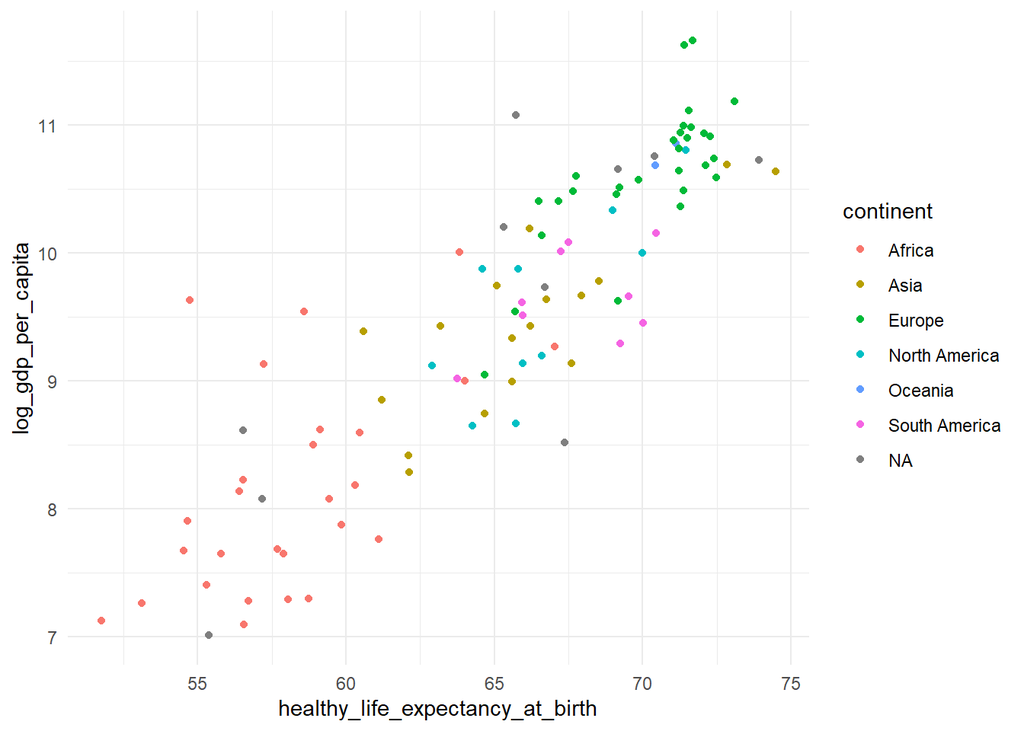

```r
ggplot() +
  geom_point(data = happy_join, aes(x = healthy_life_expectancy_at_birth, y=log_gdp_per_capita, color = continent)) +
  theme_minimal()
```

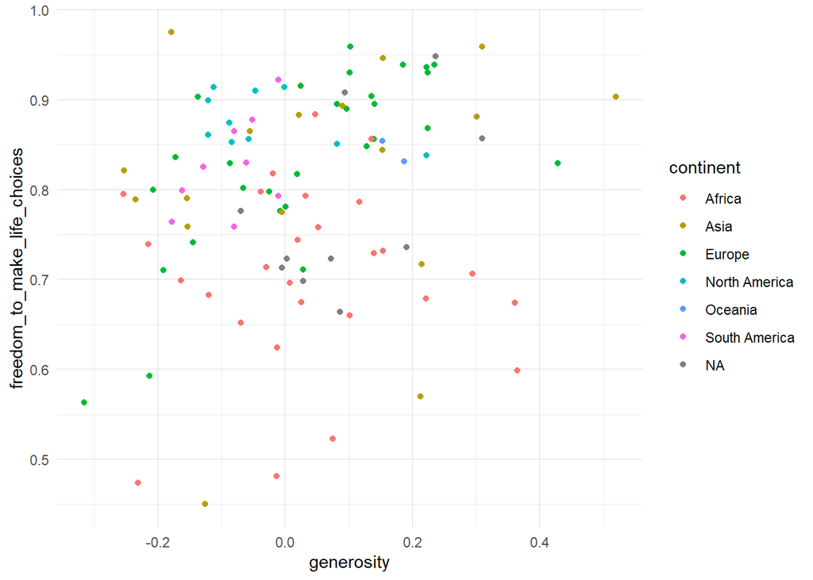

```r
ggplot() +
  geom_point(data = happy_join, aes(x = generosity, y = freedom_to_make_life_choices, color = continent)) +
  theme_minimal()
```

hard way

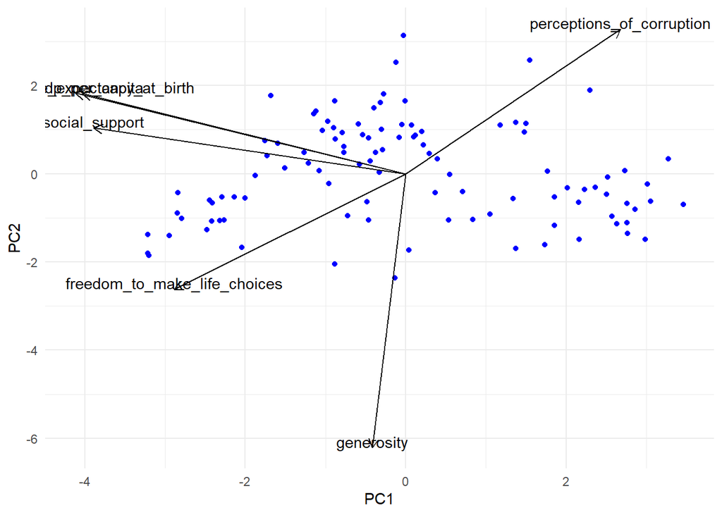

```r
# loadings_df <- data.frame(hdi_pca$rotation) %>%
happy_loadings_df <- data.frame(happy_pca$rotation * 8) %>% ### 8x multiplier is arbitrary, to extend the length of the arrows
  mutate(axis = row.names(.))

# want to plot axes and points on transformed coord sys (from x value)
happy_new_pts_df <- data.frame(happy_pca$x)

ggplot() +
  geom_point(data = happy_new_pts_df, aes(x = PC1, y = PC2),
             color = 'blue') +
  geom_segment(data = happy_loadings_df,
               x = 0, y = 0, aes(xend = PC1, yend = PC2, group = axis),
               arrow = arrow(length = unit(.25, 'cm'))) +
  geom_text(data = happy_loadings_df,
            aes(x = PC1, y = PC2, label = axis), vjust = 0, nudge_y = .01) +
  theme_minimal()
```

autoplot (uses pca to make biplot)

```r
# autoplot(happy_pca,
#       data = happy_2022,
#       loadings = TRUE,
#       colour = 'continent',
#           loadings.colour = "black",
#       loadings.label.colour = "black",
#       loadings.label.vjust = -0.5
#       ) +
#   scale_color_manual(values = c('red', 'orange', 'yellowgreen', 'darkgreen')) +
#   theme_minimal()

# ERROR: different # rows (delete the 3 repeats for now)
```

## 3.2 Summary of Biplot Major Takeaways

Screeplot by hand

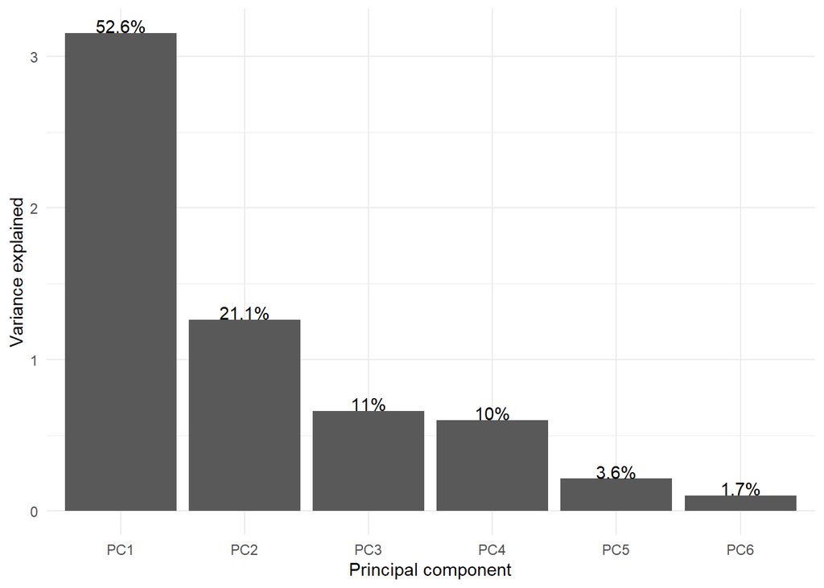

```r
# column for how much variance explains ea pt?
# variance in sdev vector, SD explained by each PC

sd_vec <- happy_pca$sdev
var_vec <- sd_vec^2 ### standard deviation is sqrt of variance!
pc_names <- colnames(happy_pca$rotation)

happy_pct_expl_df <- data.frame(v = var_vec, #values
                          pct_v = var_vec / sum(var_vec), #percent values
                          pc = pc_names) %>% #principal components?
  mutate(pct_lbl = paste0(round(pct_v*100, 1), '%')) #1 rounds to 1 decimal place, % puts a % at end

ggplot(happy_pct_expl_df, aes(x = pc, y = v)) + #v = variance, pc = PC
  geom_col() +
  geom_text(aes(label = pct_lbl), vjust = 0, nudge_y = .002) + #puts label on top
  labs(x = 'Principal component', y = 'Variance explained') +
  theme_minimal()
```

```r
# PC1: some composite of variables in some amount, diff PCs weighted in diff amnt
```

Over half (52.6%) is explained by PC1, with PC2 also contributing a good amount (21.1%)